# **ANIME RECOMMENDATION USING MYSQL**

# A. ABSTRACT

Anime is a form of hand-drawn or computer-generated animation originating from Japan. It used to be mistaken as cartoon or a child-like form of entertainment but has recently gained popularity during the Coronavirus lockdowns of 2020. The prohibition of mobility has forced people to seek recreation online, and when Netflix can no longer accommodate their tastes, that is when anime shines. And it wasn't just the visual, but studios have also invested in great soundtracks and most importantly, the plots.

Contrary to popular beliefs, anime not only provides its fan with a wide variety of genres, but also complex plots and character developments that were adapted for adults. The most common example being Shingeki di Kyojin (Attack on Titan).

Which raise the question of how could these new-comers experiences be improved and in which will be the main objective of this study.

The dataset that our study will be based on is [Anime Recommendation Database 2020](https://www.kaggle.com/hernan4444/anime-recommendation-database-2020) available on Kaggle

This dataset contains information about 17.562 anime and the preference from 325.772 different users on https://myanimelist.net/.

# B. DATASET

### I.TABLE DESCRIPTION

The database contains 4 tables saving information on the website as mentioned above. They all have missing data which is marked as Unknown because it is up for interpretation depending on the attribute. It could mean Missing Value, Others, or Not Available.

The first table "anime.csv", included all pieces of information related to the animes shown on the site.

```
Each anime has a unique code MAL_ID, Name
Score as an average of all user ratings
Genres, an anime can be classified into a list several genres
The English name, Japanese Name
Type, animes with the same name can be presented using a different type.
Aired, Premiered time written in text format
Producer, Licensors, Studios, an anime can be produced by several at a time, and different seasons can be produced by different studios
Source of content
Duration, Rating in text format
Ranked based on the score
Popularity, Members, Favorites, Watching, Completed, On-Hold, Dropped, Plan to watch - User interaction with animes
Score 10 - 1: numbers of users who gave different scores.
```

The table anime_with _synopsis.csv contains anime MAL_ID, Name, Score, Genres similar to anime.csv, and synopsis as the description of the anime.

animelist.csv contain user_id, anime_id, rating, watching status, watched_episodes. And user can rate or watch unlimited anime, watching status are identified using id

rating_complete contains user_id, anime, and rating of anime give the user has completed watching it.

watching_status includes ID of the status and status description.

### II. RELATION SCHEMA

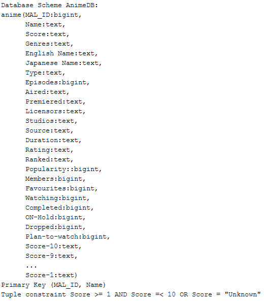

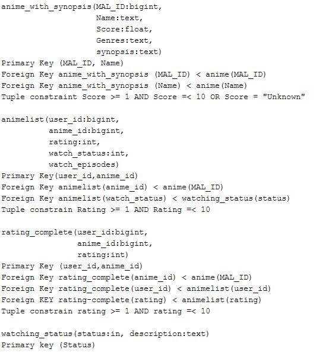

### III. ER DIAGRAM

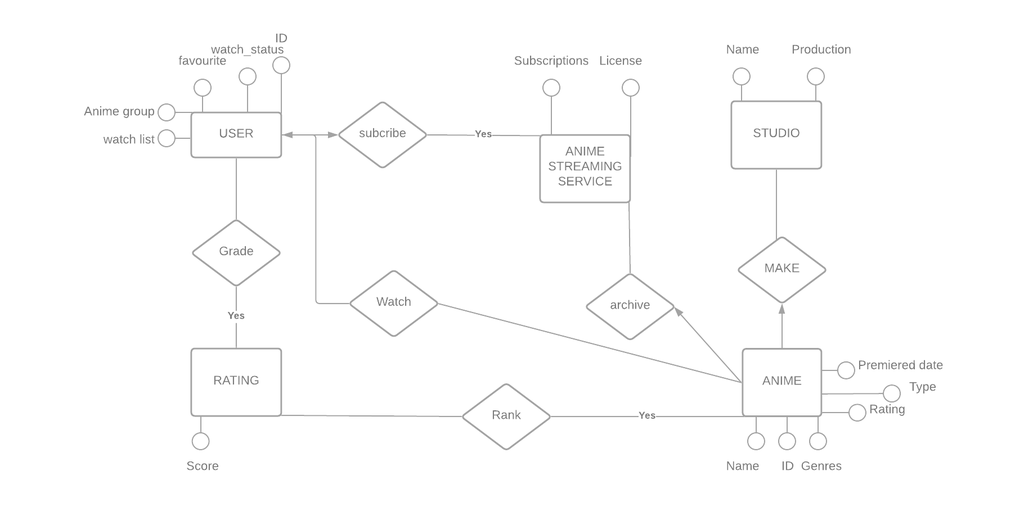

# C. APPLICATION

### I. SETTING UP OUR DEVELOPMENT ENVIRONMENT

```python
#SETTING UP OUR DEVELOPMENT ENVIRONMENT

!pip install mysql-connector-python==8.0.11 #for python 3.8
!pip install pymysql

#Using mysql.connector to connect to our MySQL database
#It can be install using the Terminal of your IDE
#using the commands above

import mysql.connector as mysql
from mysql.connector import Error
import pandas as pd
from sqlalchemy import create_engine
import pymysql
```

```
     |████████████████████████████████| 318 kB 28.1 MB/s
     |████████████████████████████████| 43 kB 2.1 MB/s
```

### II. HOW TO CONNECT GOOGLE COLAB DEVELOPMENT ENVIRONMENT TO THE LOCAL MYSQL DATABASE:

If you are running this script from your local IDE, the connection with MySQL database can be easily established using these codes:

`try:`

```
db  = mysql.connect(
                    host = "localhost",
                    user = "your username",
                    passwd = "your password")
if db.is_connected():
    cursor = db.cursor()
    cursor.execute("CREATE DATABASE AnimeDB")
    print("AnimeDB database is created")
```

`except Error as e:`

```
print("Error while connecting to MySQL",e)
```

For your local MySQL to be reachable by the Internet, you must host it in a third party server, in this case I am using ngrok. The step is as follow:

1. Download the program from https://ngrok.com/download then you will need to unzip the file and open the program.
2. To begin, connect your account using the Authtoken provided by this link https://dashboard.ngrok.com/get-started/your-authtoken. You will be asked to login or sign up. `ngrok authtoken <your_auth_token>`
3. Then for MySQL, use the command `ngrok tcp 3306`, which will display the hostname.
4. For example, from the image below, host is given by `"0.tcp.ngrok.io"`, port number is `"14892"`. Bear in mind that everytime you run ngrok, your host address and port number will change

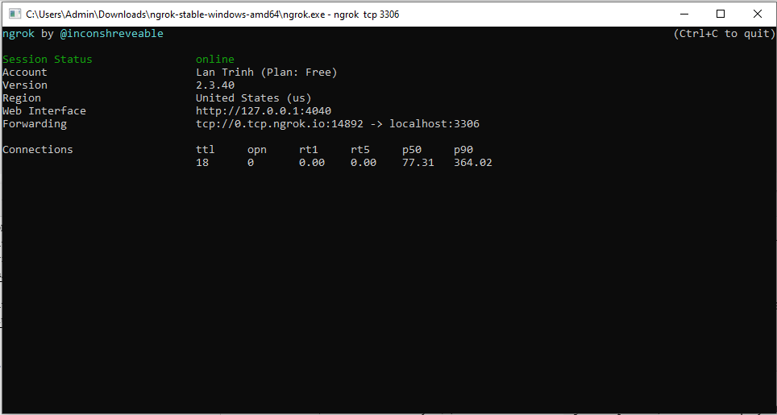

1. We will connect to our MySQL database using mysql.connector which require you to specify the host, port (as specified above) user and password as in your set up

## **NOTE**

To prevent connection timeout, i reconnect the script to the MySQL database in every cells so to run smoothly, *you must replace the host and port number in ALL(15) cells.*

Which can be easily achieve using *CTRL+H -> Input your new address -> Replace all.* like below

[figure not shown]

```python
#ESTABLISHING CONNECTION BETWEEN THE Python IDE and MySQL database
#CREATING A NEW DATABASE IF SUCCESSFUL.
try:
    db  = mysql.connect(
                        host = "0.tcp.ngrok.io",
                        port ="15219",
                        user = "Lan_Trinh",
                        passwd = "MarieCurie1691!"
                        )
    if db.is_connected():
        cursor = db.cursor()
        cursor.execute("CREATE DATABASE AnimeDB")
        print("AnimeDB database is created")

except Error as e:
    print("Error while connecting to MySQL",e)
```

```
AnimeDB database is created
```

Some errors that might occur from this step are:

1. `1007 (HY000): Can't create database 'animedb'; database exists`

This is due to the fact that you have successfully created a new database in the first run, in this case you can carry on with the next step.

1. `Error Code: 2013. Lost connection to MySQL server during query`

In which you can quickly fix by opening MySQL Workbench, go to Edit → Preferences → SQL Editor → DBMS connection read time out (in seconds): 60. And then change it 6000.

### III. READ AND INSERT DATA

To read the data using Google Colab, you must first upload your dataset to the notebook, by clicking on the File icon on the far left, then on the Upload icon and choose your data of interest.

**NOTE**: Throughout the analysis, i will be exporting outputs as csv file for better view. It will be easily accessible with the column on the left hand side, and viewed on the right hand side.

[figure not shown]

For our study, i will be using mainly the `anime.csv` file, which has 35 columns containing relevant information on different series or movies:

[*INFORMATIONS ON EACH COLUMN ARE AVAILABLE ON THE DATA PAGE*](https://www.kaggle.com/hernan4444/anime-recommendation-database-2020)

```python
#List of all animes and their related information
#Reading the csv file before adding the table in our database

anime = pd.read_csv("anime.csv")
print(anime)

synopsis = pd.read_csv("anime_with_synopsis.csv")
print(synopsis)
```

```
       MAL_ID                             Name  ...  Score-2  Score-1
0           1                     Cowboy Bebop  ...    741.0   1580.0
1           5  Cowboy Bebop: Tengoku no Tobira  ...    109.0    379.0
2           6                           Trigun  ...    316.0    533.0
3           7               Witch Hunter Robin  ...    164.0    131.0
4           8                   Bouken Ou Beet  ...     50.0     27.0
...       ...                              ...  ...      ...      ...
17557   48481  Daomu Biji Zhi Qinling Shen Shu  ...  Unknown  Unknown
17558   48483                     Mieruko-chan  ...  Unknown  Unknown
17559   48488  Higurashi no Naku Koro ni Sotsu  ...  Unknown  Unknown
17560   48491      Yama no Susume: Next Summit  ...  Unknown  Unknown
17561   48492                    Scarlet Nexus  ...  Unknown  Unknown

[17562 rows x 35 columns]
       MAL_ID  ...                                          sypnopsis
0           1  ...  In the year 2071, humanity has colonized sever...
1           5  ...  other day, another bounty—such is the life of ...
2           6  ...  Vash the Stampede is the man with a $$60,000,0...
3           7  ...  ches are individuals with special powers like ...
4           8  ...  It is the dark century and the people are suff...
...       ...  ...                                                ...
16209   48481  ...  No synopsis information has been added to this...
16210   48483  ...  ko is a typical high school student whose life...
16211   48488  ...          Sequel to Higurashi no Naku Koro ni Gou .
16212   48491  ...                          New Yama no Susume anime.
16213   48492  ...  Solar calendar year 2020: grotesque organisms ...

[16214 rows x 5 columns]
```

```python
#FOR A BIG TABLE WITH 35 COLUMNS, I DECIDED NOT TO CREATE THE TABLE
#AND DECLARE EACH VARIABLES ONE BY ONE BUT TO INSERT MY DATAFRAME IN TO
#THE DATABASE USING pandas to_sql() FUNCTION

#!!!YOU MUST ADAPT YOUR HOST ADDRESS AND PORT NUMBER EVERYTIME YOU NGROK
engine = create_engine("mysql+pymysql://{user}:{pw}@{host}:{port}/{db}"
                       .format(host="0.tcp.ngrok.io", port="15219", user="Lan_Trinh",pw="MarieCurie1691!", db="AnimeDB"))

#!!!YOU SHOULD ONLY RUN THIS CELL ONCE
anime.to_sql("anime", con = engine, if_exists = "append")
synopsis.to_sql("synopsis", con = engine, if_exists = "append")
```

What is happening?

- `"anime"` is the name of the table in which we want to insert out pandas Dataframe.
- `con = engine` provides the connection details (recall that we created engine using our authentication details in the step prior).
- `if_exists = 'append'` checks whether the table we specified already exists or not, and then append the new data (if it does exist) or creates new table(if it doesn't).

### IV. DATA CLEANING & EXPLORATION

*1. CHECK FOR DUPLICATE*

```python
#%load_ext google.colab.data_table

#reconnect to avoid connection timeout error
db = mysql.connect(
    host = "0.tcp.ngrok.io",
    port = "15219",
    user = "Lan_Trinh",
    passwd = "MarieCurie1691!",
    database = "animedb")

cursor = db.cursor()

#WE FIRST TAKE A LOOK AT OUR COMPLETE TABLE
name = """SELECT *
          FROM anime
          """
#read_sql function return the result of our query as a dataframe
print(pd.read_sql(name,db))


#CHECK FOR DUPLICATE
#We know that MAL_ID has unique values and is our PRIMARY KEY
#So now we will inspect all the anime name similar and why is that
#the query return Name, Score,
#duplicate: number as duplicate per anime name
#tot: cummulative sum of number of anime

distinct = """WITH dup
              AS(SELECT Name, Score, COUNT(*) AS duplicate
                  FROM anime
                  GROUP BY Name
                  ORDER BY duplicate DESC)
              SELECT *,
                    SUM(duplicate) OVER(
                                      ORDER BY duplicate DESC
                                      ROWS BETWEEN UNBOUNDED PRECEDING AND CURRENT ROW
                                      ) AS tot
              FROM dup"""

print(pd.read_sql(distinct,db))

result = pd.read_sql(distinct,db)

#For bettew view of the table, the output dataframe
#is converted to a csv file
#which will appear on the left hand side after refreshing
#when clicking on it, a window containing view of the data will open.
result.to_csv("distinct.csv")

#INSPECTING DUPLICATE
with_dup = """SELECT *
              FROM anime
              WHERE Name IN ('Maou Gakuin no Futekigousha: Shijou Saikyou no Maou no Shiso, Tensei shite Shison-tachi no Gakkou e',
                             'Hinamatsuri',
                              'Youkoso! Ecolo Shima')"""

result = pd.read_sql(with_dup,db)
result.to_csv("with_dup.csv")

query = """SELECT Name, Type, Source
           FROM anime
           WHERE Name IN ('Maou Gakuin no Futekigousha: Shijou Saikyou no Maou no Shiso, Tensei shite Shison-tachi no Gakkou e',
                             'Hinamatsuri',
                              'Youkoso! Ecolo Shima')"""
print(pd.read_sql(query,db))

clean = "DELETE FROM anime WHERE MAL_ID IN (48417,48418,39143)"
cursor.execute(clean)

print ("FINISH DATA CLEANING")
```

```
       index  MAL_ID  ...  Score-2  Score-1
0          0       1  ...    741.0   1580.0
1          1       5  ...    109.0    379.0
2          2       6  ...    316.0    533.0
3          3       7  ...    164.0    131.0
4          4       8  ...     50.0     27.0
...      ...     ...  ...      ...      ...
17557  17557   48481  ...  Unknown  Unknown
17558  17558   48483  ...  Unknown  Unknown
17559  17559   48488  ...  Unknown  Unknown
17560  17560   48491  ...  Unknown  Unknown
17561  17561   48492  ...  Unknown  Unknown

[17562 rows x 36 columns]
                                                    Name  ...      tot
```

[output cut: 22 more lines]

There are 17562 observations available. With attributes MAL_ID contains all UNIQUE values which act as the PRIMARY KEY. All other attributes accept for Name have UNKNOWN value which we will interpret as unavailable data.

And attribute Name contains 3 values that have duplicates, which are

- Maou Gakuin no Futekigousha: Shijou Saikyou no Maou no Shiso, Tensei shite Shison-tachi no Gakkou e
- Hinamatsuri
- Youkoso! Ecolo Shima Why is that?

*2. REASON FOR UNKNOWN SCORE*

So it might be worthwhile to investigate the reason and hopefully find a better method for evaluation.

```python
#reconnect
db = mysql.connect(
    host = "0.tcp.ngrok.io",
    port = "15219",
    user = "Lan_Trinh",
    passwd = "MarieCurie1691!",
    database = "animedb")

cursor = db.cursor()

#query return the number of rows with unknown score
unknown = """SELECT COUNT(*) as score_unknown
             FROM anime
             WHERE Score = "Unknown" """

print(pd.read_sql(unknown, db))

#we inspect why the value is unknown
unknown_row = """SELECT *
                 FROM anime
                 WHERE Score = "Unknown"
                 """
unknown = pd.read_sql(unknown_row,db)
unknown.to_csv("unknown_row.csv")
```

```
   score_unknown
0           5141
```

And upon our inspection of why many values in attributes Score are unknown, we come accross the columns Premiered and Favourites.

Because the Premiered time is written in string format " " not DATETIME, so it is not possible to extract the year using MySQL and count its occurence.

```python
#INSPECTING SOURCE OF UNKNOW SCORE

year = pd.read_csv("unknown_row.csv")
Premiered = year.loc[:,"Premiered"]

l=[]
for r in Premiered:
  if r != "Unknown":
    a = r.split()
    l.append(a[-1])

from collections import Counter
print(Counter(l))

#reconnect
db = mysql.connect(
    host = "0.tcp.ngrok.io",
    port = "15219",
    user = "Lan_Trinh",
    passwd = "MarieCurie1691!",
    database = "animedb")

cursor = db.cursor()

#for anime with unknown score,
#the query count the number of anime with a given number
#of user who like it
fav = """SELECT Favorites, COUNT(*) AS with_fav
       FROM anime
       WHERE Score = "Unknown"
       GROUP BY Favorites
       ORDER BY with_fav DESC
       """
print(pd.read_sql(fav,db))

#the average number of favourite users per all anime
avg = """SELECT AVG(Favorites) as avg_fav
         FROM anime"""
print(pd.read_sql(avg,db))

#new releases or not yet in 2021, without available score
a2021 = """SELECT Name, Score, Favorites, Premiered
           FROM anime
           WHERE Premiered LIKE '%2021'
           ORDER BY Favorites DESC """

print(pd.read_sql(a2021,db))
result = pd.read_sql(a2021,db)
result.to_csv("a2021.csv")
```

```
Counter({'2021': 86, '2017': 57, '2016': 44, '2015': 40, '2014': 39, '2018': 37, '2020': 34, '2019': 32, '2011': 31, '2007': 30, '2008': 29, '2009': 28, '2006': 26, '2013': 26, '2012': 23, '2010': 22, '2001': 14, '1992': 14, '2004': 13, '1999': 13, '2003': 13, '2005': 13, '1998': 12, '1989': 12, '19…
     Favorites  with_fav
0            0      3846
1            1       689
2            2       179
3            3        90
4            4        49
..         ...       ...
108        160         1
109         90         1
110        547         1
111        633         1
112        281         1

[113 rows x 2 columns]
```

[output cut: 16 more lines]

From above, it can be inferred that there are 2 main reasons for missing Score:

1. Premiered time:

However there are also very sought after anime that hasn't been released but already received ratings, this is due to them being based on very famous manga and very successful past seasons. It also contrast our observations on number of user who considered it their favourite.

1. Not Favourite:

Something that all these animes has in common is how little users like them. Reminded that, favourite shows the number of users who considers the anime their favourite, the average being 458 users. However for those animes without score, most of which have zero to none user who likes it.

Hypothetically, Score is our best method in evaluating how good or bad or well-perceived and anime is. Because it takes into account all the user that have watched it and have given score to it. But, is there an alternative?

*3. DATA EXPLORATION*

We will now look at all the best and worst anime by Score, but also to see if is there any attributes that can replace this method. The only radical choice would be using attributes Favourite, since it ensures that the users who rated it had watched the anime.

```python
#reconnect
db = mysql.connect(
    host = "0.tcp.ngrok.io",
    port = "15219",
    user = "Lan_Trinh",
    passwd = "MarieCurie1691!",
    database = "animedb")

cursor = db.cursor()

#TOP 10 BEST ANIME OF ALL TIME BEFORE 2021
#ordered by scores
best = """SELECT *
          FROM anime
          WHERE Score != "Unknown" AND Premiered NOT LIKE "%2021"
          ORDER BY Score DESC
          LIMIT 50
       """

#print(pd.read_sql(best,db))
pd.read_sql(best,db).to_csv("top50.csv")

#ordered by favourites
pop = """SELECT Name, Score, Favorites
         FROM anime
         WHERE Score != "unknown"
         AND Premiered != "unknown"
         AND Premiered NOT LIKE '%2021'
         ORDER BY Favorites DESC
         LIMIT 10"""

print(pd.read_sql(pop,db))

#TOP 10 WORST ANIME OF ALL TIME BEFORE 2021
#ordered by score
worst = """SELECT Name, Score, Favorites
          FROM anime
          WHERE Score != "Unknown" AND Premiered NOT LIKE "%2021"
          ORDER BY Score
          LIMIT 10
        """

print(pd.read_sql(worst,db))

#ordered by favourite
hate = """SELECT Name, Score, Favorites
         FROM anime
         WHERE Score != "unknown"
         AND Premiered != "unknown"
         AND Premiered NOT LIKE '%2021'
         ORDER BY Favorites
         LIMIT 10"""

print(pd.read_sql(hate,db))
```

```
                               Name Score  Favorites
0  Fullmetal Alchemist: Brotherhood  9.19     183914
1                       Steins;Gate  9.11     148452
2            Hunter x Hunter (2011)   9.1     147274
3                        Death Note  8.63     145201
4                Shingeki no Kyojin  8.48     129844
5                         One Piece  8.52     126645
6   Code Geass: Hangyaku no Lelouch  8.72      90487
7                Naruto: Shippuuden  8.16      84651
8           Neon Genesis Evangelion  8.32      71308
9           Shigatsu wa Kimi no Uso  8.74      69557
                           Name Score  Favorites
0  Tenkuu Danzai Skelter+Heaven  1.85         75
1            Utsu Musume Sayuri  2.01         41
2               Hametsu no Mars  2.23        278
```

[output cut: 18 more lines]

The outputs for the best anime given by ranking with attribute Favourites closely resemble that of score but perform poorly when choosing the worst animes.

We will now take at quick looks at other attributes:

**3.1 Type of anime**

```python
#reconnect
db = mysql.connect(
    host = "0.tcp.ngrok.io",
    port = "15219",
    user = "Lan_Trinh",
    passwd = "MarieCurie1691!",
    database = "animedb")

cursor = db.cursor()

#DISTRIBUTION OF ANIME TYPE
atype = """WITH numtype AS(
                          SELECT type,COUNT(*) as num_anime
                          FROM anime
                          GROUP BY type
                          ORDER BY num_anime DESC)
           SELECT *,
                  SUM(num_anime) OVER(
                                      ORDER BY num_anime DESC
                                      ROWS BETWEEN UNBOUNDED PRECEDING AND CURRENT ROW
                                      ) AS cum_tot,
                  ROUND(((num_anime/17562)*100),2) AS percent
           FROM numtype
           """
print(pd.read_sql(atype,db))
print("------------------------------------")

#Is this also the case for the TOP 50 BEST ANIME?
best_type = """
            WITH
               best AS(
                            SELECT *
                            FROM anime
                            WHERE Premiered NOT LIKE "%2021"
                            AND Score != "Unknown"
                            ORDER BY Score DESC
                            LIMIT 50),
               numtype AS(
                          SELECT type,COUNT(*) as num_anime
                          FROM best
                          GROUP BY type
                          ORDER BY num_anime DESC)
               SELECT *,
                      SUM(num_anime) OVER(
                                          ORDER BY num_anime DESC
                                          ROWS BETWEEN UNBOUNDED PRECEDING AND CURRENT ROW
                                          ) AS cum_tot,
                      ROUND(((num_anime/50)*100),2) AS percent
           FROM numtype
           """
print(pd.read_sql(best_type ,db))
```

```
      type  num_anime  cum_tot  percent
0       TV       4996   4996.0    28.45
1      OVA       3894   8890.0    22.17
2    Movie       3041  11931.0    17.32
3  Special       2218  14149.0    12.63
4      ONA       1907  16056.0    10.86
5    Music       1469  17525.0     8.36
6  Unknown         37  17562.0     0.21
------------------------------------
    type  num_anime  cum_tot  percent
0     TV         36     36.0     72.0
1  Movie         12     48.0     24.0
2    OVA          2     50.0      4.0
```

From our analysis, it is convenient to see that the most too common types are TV and Movie. TV indicates animes which come in series sometimes with multiple seasons. So we can carry our recommendation in 2 directions, for those with limited time who can only enjoy movie while other invests their in tv series.

**3.2 Source of Content**

```python
#reconnect
db = mysql.connect(
    host = "0.tcp.ngrok.io",
    port = "15219",
    user = "Lan_Trinh",
    passwd = "MarieCurie1691!",
    database = "animedb")

cursor = db.cursor()

#DISTRIBUTION OF ANIME TYPE
source = """WITH numsource AS(
                          SELECT source,COUNT(*) as num_anime
                          FROM anime
                          GROUP BY source
                          ORDER BY num_anime DESC)
           SELECT *,
                  SUM(num_anime) OVER(
                                      ORDER BY num_anime DESC
                                      ROWS BETWEEN UNBOUNDED PRECEDING AND CURRENT ROW
                                      ) AS cum_tot,
                  ROUND(((num_anime/17562)*100),2) AS percent
           FROM numsource
           """
print(pd.read_sql(source,db))
print("------------------------------------")

#Is this also the case for the TOP 50 BEST ANIME?
best_source = """
            WITH
               best AS(
                            SELECT *
                            FROM anime
                            WHERE Premiered NOT LIKE "%2021"
                            AND Score != "Unknown"
                            ORDER BY Score DESC
                            LIMIT 50),
               numsource AS(
                          SELECT source,COUNT(*) as num_anime
                          FROM best
                          GROUP BY source
                          ORDER BY num_anime DESC)
               SELECT *,
                      SUM(num_anime) OVER(
                                          ORDER BY num_anime DESC
                                          ROWS BETWEEN UNBOUNDED PRECEDING AND CURRENT ROW
                                          ) AS cum_tot,
                      ROUND(((num_anime/50)*100),2) AS percent
           FROM numsource
           """
print(pd.read_sql(best_source ,db))
```

```
           source  num_anime  cum_tot  percent
0        Original       5215   5215.0    29.69
1           Manga       3825   9040.0    21.78
2         Unknown       3567  12607.0    20.31
3    Visual novel        993  13600.0     5.65
4            Game        880  14480.0     5.01
5     Light novel        768  15248.0     4.37
6           Other        597  15845.0     3.40
7           Novel        510  16355.0     2.90
8           Music        317  16672.0     1.81
9    4-koma manga        288  16960.0     1.64
10      Web manga        252  17212.0     1.43
11   Picture book        147  17359.0     0.84
12           Book        112  17471.0     0.64
13      Card game         64  17535.0     0.36
14  Digital manga         15  17550.0     0.09
15          Radio         12  17562.0     0.07
------------------------------------
         source  num_anime  cum_tot  percent
0         Manga         31     31.0     62.0
1      Original          7     38.0     14.0
2   Light novel          4     42.0      8.0
3  Visual novel          3     45.0      6.0
4     Web manga          3     48.0      6.0
5         Novel          2     50.0      4.0
```

**3.3 Production Studios**

```python
#reconnect
db = mysql.connect(
    host = "0.tcp.ngrok.io",
    port = "15219",
    user = "Lan_Trinh",
    passwd = "MarieCurie1691!",
    database = "animedb")

cursor = db.cursor()

#DISTRIBUTION OF ANIME TYPE
Studios = """WITH numStudios AS(
                          SELECT Studios,COUNT(*) as num_anime
                          FROM anime
                          GROUP BY Studios
                          ORDER BY num_anime DESC)
           SELECT *,
                  SUM(num_anime) OVER(
                                      ORDER BY num_anime DESC
                                      ROWS BETWEEN UNBOUNDED PRECEDING AND CURRENT ROW
                                      ) AS cum_tot,
                  ROUND(((num_anime/17562)*100),2) AS percent
           FROM numStudios
           """
print(pd.read_sql(Studios,db))
print("------------------------------------")

#Is this also the case for the TOP 50 BEST ANIME?
best_Studios = """
            WITH
               best AS(
                            SELECT *
                            FROM anime
                            WHERE Premiered NOT LIKE "%2021"
                            AND Score != "Unknown"
                            ORDER BY Score DESC
                            LIMIT 50),
               numStudios AS(
                          SELECT Studios,COUNT(*) as num_anime
                          FROM best
                          GROUP BY Studios
                          ORDER BY num_anime DESC)
               SELECT *,
                      SUM(num_anime) OVER(
                                          ORDER BY num_anime DESC
                                          ROWS BETWEEN UNBOUNDED PRECEDING AND CURRENT ROW
                                          ) AS cum_tot,
                      ROUND(((num_anime/50)*100),2) AS percent
           FROM numStudios
           """
print(pd.read_sql(best_Studios ,db))
```

```
                           Studios  num_anime  cum_tot  percent
0                          Unknown       7079   7079.0    40.31
1                   Toei Animation        755   7834.0     4.30
2                          Sunrise        479   8313.0     2.73
3                        J.C.Staff        358   8671.0     2.04
4                         Madhouse        324   8995.0     1.84
...                            ...        ...      ...      ...
1084        10Gauge, Studio DURIAN          1  17558.0     0.01
1085                       Irawias          1  17559.0     0.01
1086  SILVER LINK., Studio Palette          1  17560.0     0.01
1087  Fanworks, Space Neko Company          1  17561.0     0.01
1088                  Studio Kafka          1  17562.0     0.01

[1089 rows x 4 columns]
------------------------------------
```

[output cut: 23 more lines]

**3.4 Age Rating**

```python
#reconnect
db = mysql.connect(
    host = "0.tcp.ngrok.io",
    port = "15219",
    user = "Lan_Trinh",
    passwd = "MarieCurie1691!",
    database = "animedb")

cursor = db.cursor()

#DISTRIBUTION OF ANIME TYPE
Rating = """WITH numRating AS(
                          SELECT Rating,COUNT(*) as num_anime
                          FROM anime
                          GROUP BY Rating
                          ORDER BY num_anime DESC)
           SELECT *,
                  SUM(num_anime) OVER(
                                      ORDER BY num_anime DESC
                                      ROWS BETWEEN UNBOUNDED PRECEDING AND CURRENT ROW
                                      ) AS cum_tot,
                  ROUND(((num_anime/17562)*100),2) AS percent
           FROM numRating
           """
print(pd.read_sql(Rating,db))
print("------------------------------------")

#Is this also the case for the TOP 50 BEST ANIME?
best_R = """
            WITH
               best AS(
                            SELECT *
                            FROM anime
                            WHERE Premiered NOT LIKE "%2021"
                            AND Score != "Unknown"
                            ORDER BY Score DESC
                            LIMIT 50),
               numRating AS(
                          SELECT Rating,COUNT(*) as num_anime
                          FROM best
                          GROUP BY Rating
                          ORDER BY num_anime DESC)
               SELECT *,
                      SUM(num_anime) OVER(
                                          ORDER BY num_anime DESC
                                          ROWS BETWEEN UNBOUNDED PRECEDING AND CURRENT ROW
                                          ) AS cum_tot,
                      ROUND(((num_anime/50)*100),2) AS percent
           FROM numRating
           """
print(pd.read_sql(best_R ,db))
```

```
                           Rating  num_anime  cum_tot  percent
0       PG-13 - Teens 13 or older       6132   6132.0    34.92
1                    G - All Ages       5782  11914.0    32.92
2                   PG - Children       1461  13375.0     8.32
3                     Rx - Hentai       1345  14720.0     7.66
4  R - 17+ (violence & profanity)       1157  15877.0     6.59
5                R+ - Mild Nudity        997  16874.0     5.68
6                         Unknown        688  17562.0     3.92
------------------------------------
                           Rating  num_anime  cum_tot  percent
0       PG-13 - Teens 13 or older         31     31.0     62.0
1  R - 17+ (violence & profanity)         16     47.0     32.0
2                   PG - Children          1     48.0      2.0
3                R+ - Mild Nudity          1     49.0      2.0
4                    G - All Ages          1     50.0      2.0
```

**3.5 Anime Genres of the TOP 50**

Anime Genres is saved as Text Datatype in our database and is presented as a list of genres separated by a comma.

Since MySQL doesn't support the command UNNEST, we must once a gain use the help of Python to unpack our lists, and count the number of occurence of each genre.

Note that the sum of genre occurences will not be equal to the number of anime we have, since each anime consists of several genres, so the data is repetitive.

```python
def Count(colname,tablename):
  input = tablename.loc[:,colname]
  output = []
  for row in input:
    out  = row.split(", ")
    for word in out:
      output.append(word)
  counter = Counter(output)
  i = 0
  for val,count in counter.most_common():
    print(val,count)
    i += 1
  print("The number of genres is:{}".format(i))

print("ANIME GENRES RANKED BY MOST COMMON:")
Count("Genres",anime)
print("-------------------------------------")

print("MOST COMMON GENRES OF TOP 50 ANIME:")
top = pd.read_csv("top50.csv")
Count("Genres",top)
```

```
ANIME GENRES RANKED BY MOST COMMON:
Comedy 6029
Action 3888
Fantasy 3285
Adventure 2957
Kids 2665
Drama 2619
Sci-Fi 2583
Music 2244
Shounen 2003
Slice of Life 1914
Romance 1899
School 1642
Supernatural 1479
Hentai 1348
Historical 1144
Mecha 1101
Magic 1081
Seinen 830
Ecchi 767
Mystery 727
Sports 713
Shoujo 688
Parody 660
Super Power 632
Military 576
Dementia 512
Demons 501
Space 495
Horror 462
Martial Arts 425
Harem 399
Game 386
Psychological 345
Police 247
Samurai 202
Vampire 136
Cars 133
Thriller 131
Shounen Ai 100
```

[output cut: 27 more lines]

```
Vampire 3
Mecha 3
Magic 2
Thriller 2
Space 2
Psychological 2
Demons 2
Game 1
Josei 1
Horror 1
Police 1
Music 1
Martial Arts 1
Shoujo 1
The number of genres is:33
```

### V. MAKING RECOMMENDATION - Relevant queries

*1.ANIMES TO LOOK FORWARD TO IN 2021*

The query will return all names of anime that will premiere in 2021, ranked by popularity among user and their synopsis

```python
#since the table synopsis contain less observations than anime, we will check for the anime missing
#reconnect
db = mysql.connect(
    host = "0.tcp.ngrok.io",
    port = "15219",
    user = "Lan_Trinh",
    passwd = "MarieCurie1691!",
    database = "animedb")

cursor = db.cursor()

to2021 = """SELECT a.MAL_ID,a.Name, a.Premiered, s.sypnopsis
            FROM anime AS a LEFT JOIN synopsis AS s
              ON a.MAL_ID = s.MAL_ID AND a.Name = s.Name
            WHERE a.Premiered LIKE '%2021'
            ORDER BY a.Popularity"""

print(pd.read_sql(to2021,db))
pd.read_sql(to2021,db).to_csv("to2021.csv")
```

```
     MAL_ID  ...                                          sypnopsis
0     40028  ...  Gabi Braun and Falco Grice have been training ...
1     39617  ...  Emma, Ray, and the rest of the older children ...
2     40852  ...  Senkuu has made it his goal to bring back two ...
3     42897  ...  On the surface, the thought of Kyouko Hori and...
4     42203  ...  Second half of Re:Zero kara Hajimeru Isekai Se...
..      ...  ...                                                ...
136   47623  ...  No synopsis information has been added to this...
137   48470  ...  The stage is Shibuya. When Ryuuhei Oda was in ...
138   48488  ...          Sequel to Higurashi no Naku Koro ni Gou .
139   48466  ...  In the year 2061 AD, Japan has lost its sovere...
140   48492  ...  Solar calendar year 2020: grotesque organisms ...

[141 rows x 4 columns]
```

*2. ANIME WITH SEVERAL SEASONS*

Usually for TV and OVA, there are multiple seasons instead of 1 because many of which are based on an ongoing Manga. To confirm this, we generate a query which return the name of TV or OVA anime series in order of alphabetical and their sources.

Given that it is true, we will now look at a few CLASSIC animes with multiple season. With some of these famous anime, they not only come as TV show, but also movies and others. These anime are some of the names we got from the Top 50 best anime:

- Fullmetal Alchemist
- Steins:Gate
- Hunter x Hunter
- Gintaima
- Shingeki no Kyojin
- Code Geass
- Haikyuu

```python
db = mysql.connect(
    host = "0.tcp.ngrok.io",
    port = "15219",
    user = "Lan_Trinh",
    passwd = "MarieCurie1691!",
    database = "animedb")

cursor = db.cursor()

season = """SELECT Name, Source
            FROM anime
            WHERE Type IN ('TV','OVA')
            ORDER BY Name
            LIMIT 20"""

print(pd.read_sql(season,db))
print("-------------------------------")

#Lets inspect Shingeki no Kyojin

AOT = """WITH AOT AS(SELECT *
                      FROM anime
                      WHERE Name LIKE '%Shingeki no Kyojin%')
         SELECT COUNT(DISTINCT(Name)) as num_release,
                COUNT(DISTINCT(Type)) as num_type,
                COUNT(DISTINCT(Studios)) as num_studio,
                AVG(Score) as Avg_Score,
                MIN(Score) as lowest,
                MAX(Score) as highest
         FROM AOT"""

rating = """SELECT DISTINCT(Rating), COUNT(*) AS count
            FROM Anime
            WHERE Name LIKE '%Shingeki no Kyojin%'
            GROUP BY Rating"""

genre = """SELECT Genres
           FROM Anime
           WHERE Name Like '%Shingeki no Kyojin%'
           AND Score = 9.17"""

print(pd.read_sql(AOT,db))
print(pd.read_sql(rating,db))
print(pd.read_sql(genre,db))
#pd.read_sql(AOT,db).to_csv("AOT.csv")
```

```
                                            Name        Source
0                                        _Summer  Visual novel
1                           .hack//G.U. Returner          Game
2                                    .hack//Gift      Original
3                              .hack//Liminality      Original
4                                 .hack//Quantum      Original
5                                   .hack//Roots      Original
6                                    .hack//Sign      Original
7              .hack//Tasogare no Udewa Densetsu         Manga
8      "Bungaku Shoujo" Kyou no Oyatsu: Hatsukoi   Light novel
9                       "Bungaku Shoujo" Memoire   Light novel
10                                        "Eiji"         Manga
11  "Eikou Naki Tensai-tachi" Kara no Monogatari         Manga
12                                "Eiyuu" Kaitai   Light novel
13                                     ** Kouhai         Manga
14                                  0-sen Hayato         Manga
15                            0-sen Hayato Pilot         Manga
16                                         009-1         Manga
17                                      07-Ghost         Manga
18                       1-gatsu ni wa Christmas         Manga
19    1-ri Botchi no Ookami to 7-hiki no Ko Yagi          Book
-------------------------------
   num_release  num_type  num_studio  Avg_Score lowest highest
0           18         4           4   7.793333   6.52    9.17
                           Rating  count
0  R - 17+ (violence & profanity)     14
1       PG-13 - Teens 13 or older      2
2                    G - All Ages      2
                                              Genres
0  Action, Military, Mystery, Super Power, Drama,...
```

Now, we shall make a recommendation for someone who enjoys Shingeki no Kyojin. We will write a query which return a list of anime names,scores, and sypnosis. Given that these animes have the same rating, share at least two similar genres with grades greater or equal to the average score 7.7.

```python
db = mysql.connect(
    host = "0.tcp.ngrok.io",
    port = "15219",
    user = "Lan_Trinh",
    passwd = "MarieCurie1691!",
    database = "animedb")

cursor = db.cursor()

recommend = """WITH joined AS(
                              SELECT a.Name, a.Score, s.sypnopsis
                              FROM anime AS a LEFT JOIN synopsis AS s
                              ON a.MAL_ID = s.MAL_ID AND a.Name = s.Name
                              WHERE a.Name NOT LIKE '%Shingeki no Kyojin%'
                                    AND a.Rating LIKE "%violence & profanity%"
                                    AND a.Score > 7.7
                                    AND a.Genres LIKE '%Super Power%'
                                    AND a.Genres LIKE '%Drama%'
                              ORDER BY a.Score DESC)
               SELECT *
               FROM joined"""

print(pd.read_sql(recommend,db))
#pd.read_sql(recommend,db).to_csv("AOT_rec.csv")
```

```
                                 Name  ...                                          sypnopsis
0  Code Geass: Hangyaku no Lelouch R2  ...  One year has passed since the Black Rebellion,...
1     Code Geass: Hangyaku no Lelouch  ...  In the year 2010, the Holy Empire of Britannia...
2  Wu Liuqi Zhi Zui Qiang Fa Xing Shi  ...  Seeking to recover his memories, a scissor-wie...
3     Code Geass: Fukkatsu no Lelouch  ...  Since the demise of the man believed to be Bri...
4                       Cike Wu Liuqi  ...  To the casual eye, the amnesiac bounty hunter ...
5                            Gungrave  ...  Brandon Heat and Harry MacDowel, two friends s...
6       Shin Mazinger Shougeki! Z-hen  ...  Set in the near future, humanity enters anothe...

[7 rows x 3 columns]
```

*3.ANIME MOVIE RECOMMENDATION*

For people living a busy life style, finishing several seasons or just one might be impossible but fear not.

Most people learned about anime through movies coming from studio Ghibli and so we will try to make recommendation based on 10 of their best works according to users, making it an easy and gentle introduction to anime.

```python
db = mysql.connect(
    host = "0.tcp.ngrok.io",
    port = "15219",
    user = "Lan_Trinh",
    passwd = "MarieCurie1691!",
    database = "animedb")

cursor = db.cursor()

ghibli = """
            SELECT *
            FROM anime as a
            WHERE a.Studios = 'Studio Ghibli'
            AND a.type = 'Movie'
            ORDER BY a.Score DESC
            LIMIT 10
                          """

info = """WITH ghibli AS(SELECT *
                        FROM anime
                        WHERE Studios = "Studio Ghibli")
         SELECT COUNT(DISTINCT(Name)) as num_release,
                COUNT(DISTINCT(Source)) as num_source,
                COUNT(DISTINCT(Rating)) as num_rating,
                AVG(Score) as Avg_Score,
                MIN(Score) as lowest,
                MAX(Score) as highest
         FROM ghibli"""

rating = """SELECT DISTINCT(Rating), COUNT(*) AS count
            FROM Anime
            WHERE Studios LIKE 'Studio Ghibli'
            GROUP BY Rating
            """

genre = """SELECT Genres
           FROM Anime
           WHERE Studios Like 'Studio Ghibli'
           AND Score = 8.83"""

print(pd.read_sql(ghibli,db))
pd.read_sql(ghibli,db).to_csv("ghibli.csv")
print(pd.read_sql(info,db))
print(pd.read_sql(rating,db))
print(pd.read_sql(genre,db))
```

```
   index  MAL_ID                           Name  ... Score-3 Score-2 Score-1
0    176     199  Sen to Chihiro no Kamikakushi  ...   856.0   489.0  1174.0
1    142     164                  Mononoke Hime  ...   545.0   283.0   702.0
2    404     431            Howl no Ugoku Shiro  ...   737.0   351.0   668.0
3    542     578                 Hotaru no Haka  ...   953.0   539.0   845.0
4    480     513         Tenkuu no Shiro Laputa  ...   242.0   119.0   131.0
5    490     523               Tonari no Totoro  ...   804.0   351.0   621.0
6    479     512             Majo no Takkyuubin  ...   229.0   105.0   121.0
7    548     585               Mimi wo Sumaseba  ...   220.0   105.0   198.0
8   7492   16664      Kaguya-hime no Monogatari  ...   222.0   118.0   111.0
9   7491   16662                   Kaze Tachinu  ...   344.0   171.0   161.0

[10 rows x 36 columns]
   num_release  num_source  num_rating  Avg_Score lowest highest
0           50           8           3      6.876   4.75    8.83
                      Rating  count
0  PG-13 - Teens 13 or older      5
1              PG - Children      9
2               G - All Ages     36
                           Genres
0  Adventure, Supernatural, Drama
```

Now we shall make a recommendation for anime movies (other Ghibli movies included) that share some characteristics with Ghibli movies in general and Spirited Away.

```python
db = mysql.connect(
    host = "0.tcp.ngrok.io",
    port = "15219",
    user = "Lan_Trinh",
    passwd = "MarieCurie1691!",
    database = "animedb")

cursor = db.cursor()

movie = """WITH rec AS(
                        SELECT a.Name, a.Score, s.sypnopsis
                        FROM anime AS a LEFT JOIN synopsis AS s
                          ON a.MAL_ID = s.MAL_ID AND a.Name = s. Name
                        WHERE a.Type = "Movie"
                        AND a.Rating LIKE "%All Ages%"
                        AND a.Genres LIKE "%Adventure%"
                        AND a.Genres LIKE "%Drama%"
                        AND a.Score >= 6.8
                        ORDER BY a.Score DESC)
            SELECT *
            FROM rec """

print(pd.read_sql(movie,db))
pd.read_sql(movie,db).to_csv("Ghibli_rec.csv")
```

```
                                               Name  ...                                          sypnopsis
0                               Howl no Ugoku Shiro  ...  That jumbled piece of architecture, that cacop...
1                      Luo Xiao Hei Zhan Ji (Movie)  ...  prequel film to the Luo Xiao Hei Zhan Ji web a...
2                                Majo no Takkyuubin  ...  Kiki, a 13-year-old witch-in-training, must sp...
3                             Toki wo Kakeru Shoujo  ...  akoto Konno is in her last year of high school...
4                                   Kurenai no Buta  ...  fter a curse turned him into a pig, World War ...
5                                  Neko no Ongaeshi  ...  High school student Haru Yoshioka is bored wit...
6                                 Arashi no Yoru ni  ...  story about a goat and a wolf who become frien...
7                                     Piano no Mori  ...  Piano no Mori tells the story of Shuuhei Amami...
8                            Madang-eul Naon Amtalg  ...  Korean animation about a hen named Leafie who ...
9                                    Mirai no Mirai  ...  In a quiet corner of the city, four-year-old K...
10                                            Oseam  ...  The animation is based on the fairy tale of th...
11                 Marco: Haha wo Tazunete Sanzenri  ...  In the 19th century, Genoa (Italy), 9-year-old...
12  Chiisana Eiyuu: Kani to Tamago to Toumei Ningen  ...  odest Heroes will consist of three shorts by t...
13                    Kumo no You ni Kaze no You ni  ...  Ginga, a small town girl sets out to become th...

[14 rows x 3 columns]
```

```python
%%shell
jupyter nbconvert --to html /content/Anime.ipynb
```

```
[NbConvertApp] Converting notebook /content/Anime.ipynb to html
[NbConvertApp] Writing 728152 bytes to /content/Anime.html
```